# DATA 621 Blog 3

Andrew Bowen

2023-11-20

In this blog post I’ll be looking to create a generalized linear model. I’m basing some work off this [DataCamp GLM Tutorial](https://www.datacamp.com/tutorial/generalized-linear-models) as a reference

```r
lm1 <- lm(Deaths ~ Age + Country + Wyears, cervical)

summary(lm1)
```

```
##
## Call:
## lm(formula = Deaths ~ Age + Country + Wyears, data = cervical)
##
## Residuals:
##     Min      1Q  Median      3Q     Max
## -825.77 -159.95  -11.18  236.64  478.60
##
## Coefficients:
##                   Estimate Std. Error t value Pr(>|t|)
## (Intercept)     -1.918e+02  3.183e+02  -0.603 0.563483
## Age35to44       -4.644e+01  3.468e+02  -0.134 0.896797
## Age45to54        6.817e+02  3.484e+02   1.956 0.086139 .
## Age55to64        8.337e+02  3.496e+02   2.385 0.044228 *
## CountryEngWales  2.080e+03  3.732e+02   5.573 0.000527 ***
## CountryFrance    6.581e+02  3.179e+02   2.070 0.072197 .
## CountryItaly     4.541e+02  3.199e+02   1.420 0.193503
## Wyears          -1.092e-02  4.279e-03  -2.553 0.034026 *
## ---
## Signif. codes:  0 '***' 0.001 '**' 0.01 '*' 0.05 '.' 0.1 ' ' 1
##
## Residual standard error: 443.2 on 8 degrees of freedom
## Multiple R-squared:  0.8748, Adjusted R-squared:  0.7652
## F-statistic: 7.982 on 7 and 8 DF,  p-value: 0.004438
```

Let’s create a plot of our linear model to see how well of a fit we’re getting.

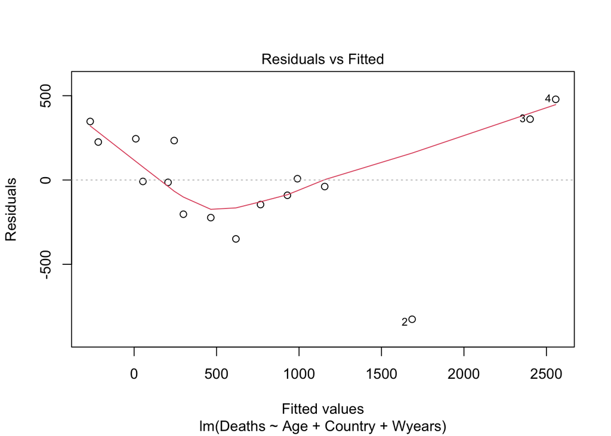

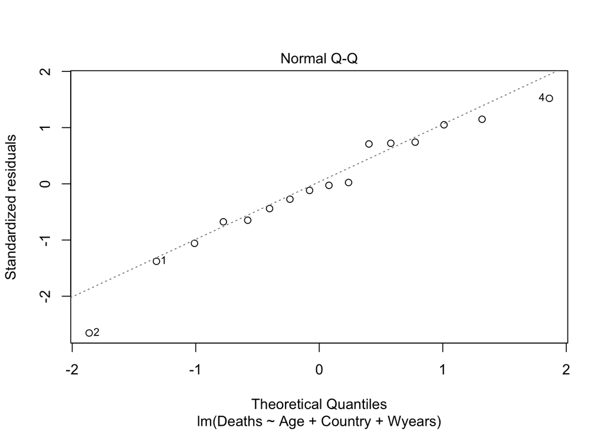

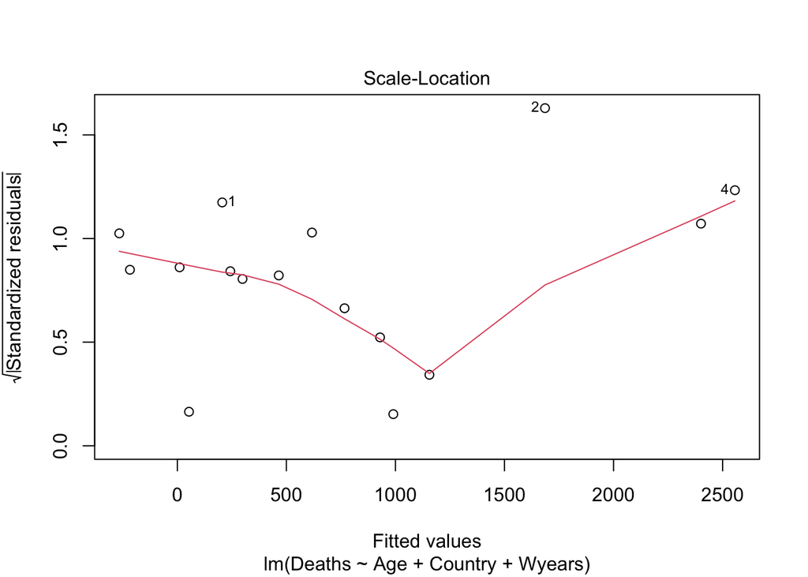

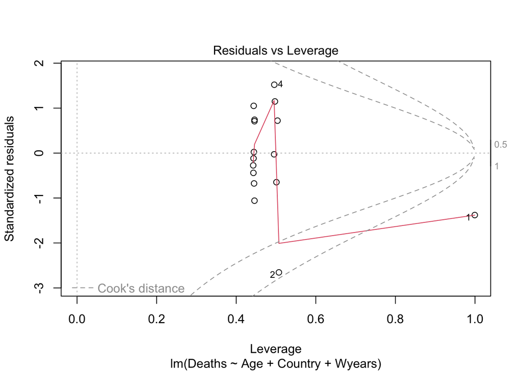

```r
plot(lm1)
```

We can see from the *Residuals vs Fitted* graph that our residuals from a basic linear model have a general pattern. Let’s plot a histogram of our residuals in order to see if they are normally distributed, which is an assumption of linearity when modeling.

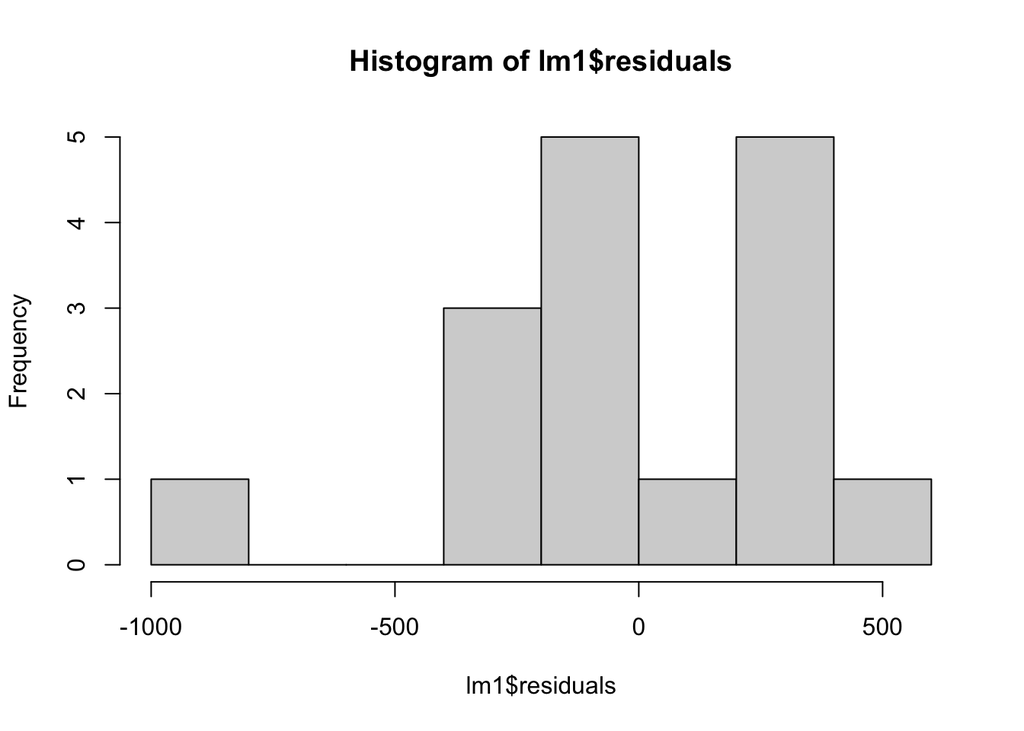

```r
hist(lm1$residuals)
```

```r
AIC(lm1)
```

```
## [1] 247.3235
```

We can now build a generalized linear model using the R function `glm`. Given we’re dealing with count data (number of deaths), we can pass the `family=poisson` parameter to model based off the Poisson distribution.

```r
glm1 <- glm(Deaths ~ Age + Country + Wyears, family="poisson", data=cervical)
summary(glm1)
```

```
##
## Call:
## glm(formula = Deaths ~ Age + Country + Wyears, family = "poisson",
##     data = cervical)
##
## Deviance Residuals:
##     Min       1Q   Median       3Q      Max
## -3.4029  -1.6002  -0.0286   0.9339   4.9031
##
## Coefficients:
##                   Estimate Std. Error z value Pr(>|z|)
## (Intercept)      2.857e+00  9.317e-02   30.66   <2e-16 ***
## Age35to44        1.577e+00  8.752e-02   18.02   <2e-16 ***
## Age45to54        2.593e+00  8.538e-02   30.38   <2e-16 ***
## Age55to64        2.722e+00  8.559e-02   31.80   <2e-16 ***
## CountryEngWales  2.439e+00  4.472e-02   54.54   <2e-16 ***
## CountryFrance    1.503e+00  4.619e-02   32.55   <2e-16 ***
## CountryItaly     1.080e+00  4.863e-02   22.21   <2e-16 ***
## Wyears          -1.697e-07  8.077e-07   -0.21    0.834
## ---
## Signif. codes:  0 '***' 0.001 '**' 0.01 '*' 0.05 '.' 0.1 ' ' 1
##
## (Dispersion parameter for poisson family taken to be 1)
##
##     Null deviance: 13857.502  on 15  degrees of freedom
## Residual deviance:    68.105  on  8  degrees of freedom
## AIC: 206.22
##
## Number of Fisher Scoring iterations: 4
```

We can use the [Akaike Information Criterion](https://en.wikipedia.org/wiki/Akaike_information_criterion) as a measure of goodness of fit of our model. In general, a minimized AIC value is preferred, and our GLM is seeing better performance out of our poisson-based GLM (206) than our regular linear model (247)

Let’s take a look at our adjusted-$R^2$ values as well. Our linear model produced an $R^2$ value of 0.7652. By contrast, our GLM produced an adjuster $R^2$ of

```r
with(summary(glm1), 1 - deviance/null.deviance)
```

```
## [1] 0.9950853
```

Which is an improvement from the linear model!